# Mid-term Project: House Price Prediction in Nashville

XD - Yixuan Hu & Shuchang Dong

November 9, 2018

## 1 Introduction

This project is a predictive model of home prices in Nashville for *Zillow* based on OLS regression. The purpose is to make use of as sufficient local statistics as we can to give an accurate prediction of the house price. The most challenging part of this exercise is to gather all the data that we think would be helpful, and put the data into our model to test whether it is as important as we suppose. It takes a lot of effort to do this, and out method is: firstly, test all the data provided by the class, and filter all the useful ones. Secondly, download related data from the website, as well as census data, and put them into our model one by one to measure their significance. Our result is that the most potent external factor that determines the sale price is the average sale price of surrounding houses, the school district also plays an important part. For the internal factors, the ones related to the area of the house are more important than others.

## 2 Data

**Methods** for gathering the data:  
- The internal characters and sale locations are from primary dataset  
- Crimes, parks, school districts, and zipcode are from: https://data.nashville.gov/  
- All the demographic information is from census data: https://factfinder.census.gov/  
- Other data such as house districts are from Tennessee: http://tn-tnmap.opendata.arcgis.com/

The variables used in the model are listed below:

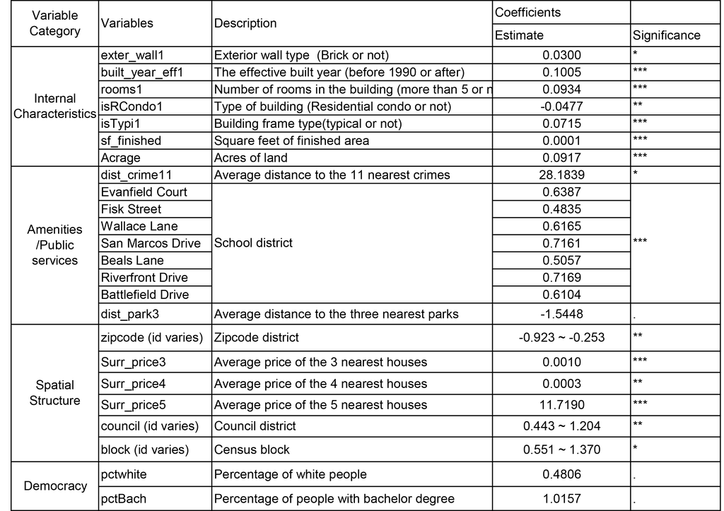

#### *Correlation Matrix of Numeric Variables*

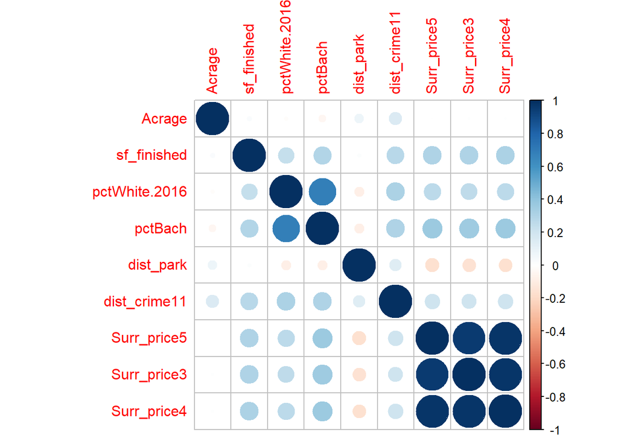

The correlation matrix of the numerical variables is presented above. The higher the value associated with two variables, the more similar they are. Please noted that the sale price of the nearest 3/4/5 houses are included because they can make the model more powerful.

#### *House Prices in Nashville*

The map of the dependent variable - house sale price - is presented below.

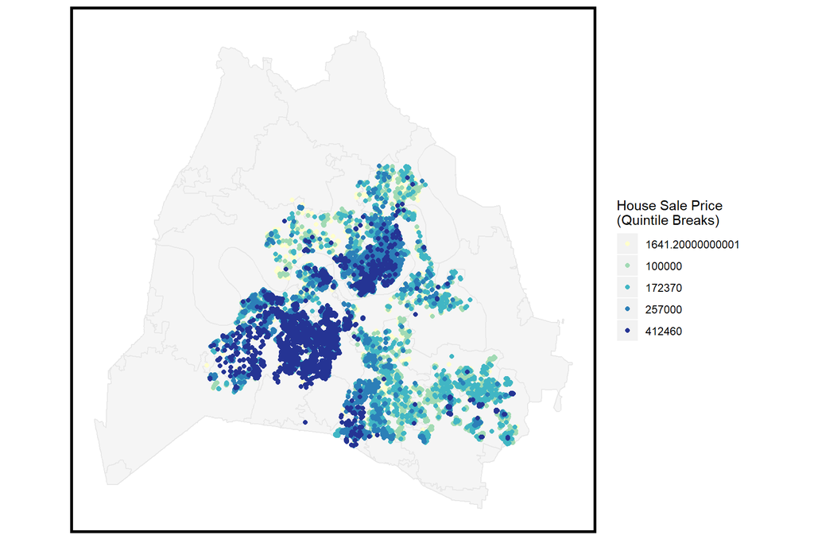

From the map of the current home price in Nashville, we could see obviously the sale price has a strong relationship with its geographical location: the closer to the center city, the higher sale price would be.

#### *Sale Price of Surrounding Houses*

Among all the predictors, here are the three most noticeable ones - the sale price of **surrounding house**, the distance to **incidents** reported to police, and the school district where the property is in. Interestingly, all of them indicate the local geographical characteristics around the houses. We presented these three predictors in maps:

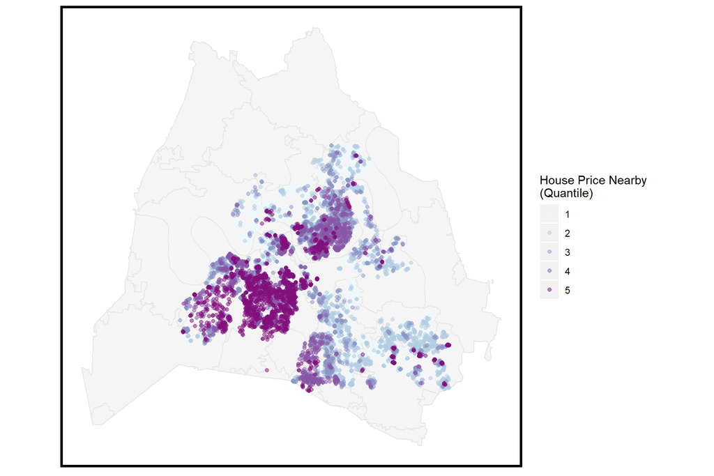

From the map above we can see that the surrounding housing prices have a similar spatial distribution with the sale price. Therefore, the surrounding prices could be an effective predictor.

#### *Proximity to Crime*

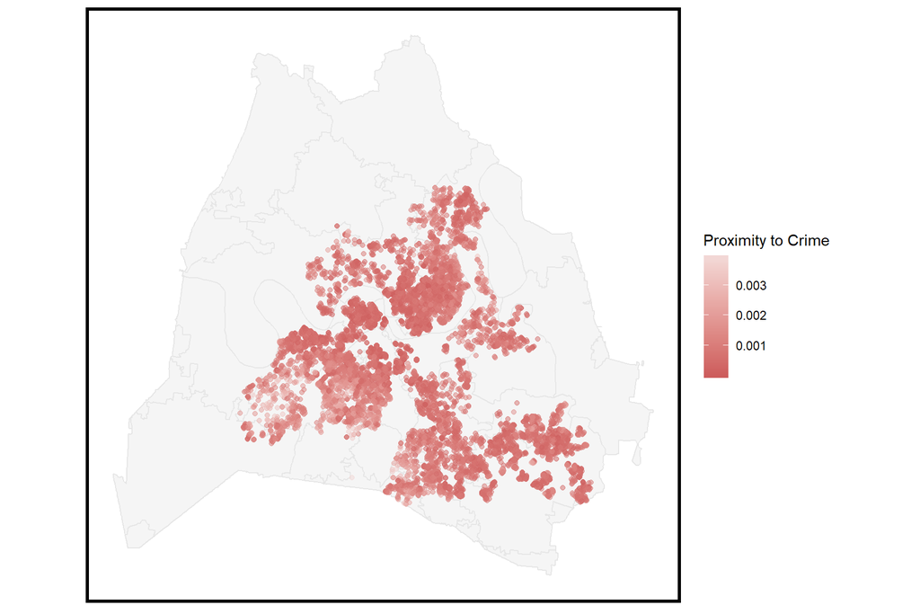

Comparing the Proximity to Crime map and the House Sale Price map, we can notice that places where are closer to the reported incidents have a lower sale price.

#### *School District*

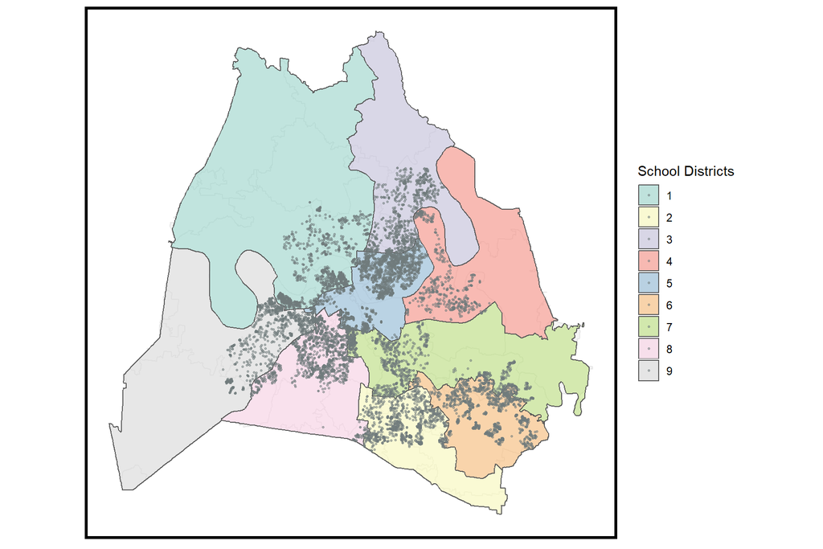

We believe that there are qualitative differences among the 9 school districts, which could play a huge role for buyers who have school-age kids.

#### *House Price as a Function of Internal Characteristics*

Except for the area of the house, we would like to see if the other internal features also play an important role.

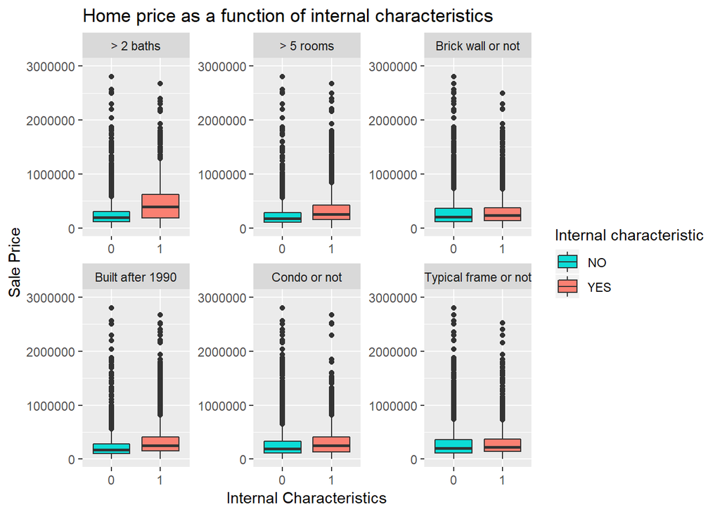

As shown in the diagram above, the number of rooms and bathrooms of the house clearly have an influence on the sale price. The residential condo tends to be more expensive than other types as a whole. The buildings that were built after 1990 are generally of the higher price than the older ones.

## 3 Method

The OLS regression model that we used in this project could be explained as “finding the minimum total absolute difference between the actual value and the predicted value.” As shown in the picture below, the regression line achieves the minimum sum of the square of the vertical distance from each point to the line.

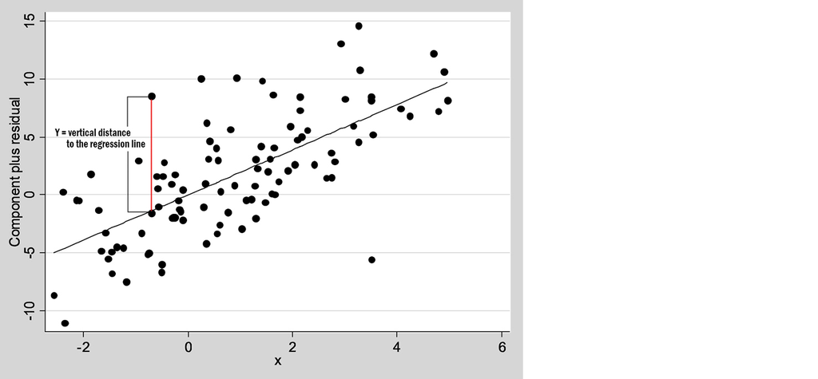

Our approach could be best described as four steps:

1. Find possible data that may be of high significance;
2. Add the data into the model to check if there is a strong relationship with the sale price;
3. If the data does have a relationship with the sale price, then further analyze the value of the data to see if the value could be simplified as fewer categories.
4. After we have got the model, we will check if it is generalizable through cross- validation: randomly selected a part of the sales as the test set and predicted the sale price of them, and repeat this process for several times. By comparing the predicted value and the actual value of the test set we will know if our model is generalizable enough for the whole data set.

## 4 Results

#### *In-sample Model Results*

Presented below is the in-sample model results.

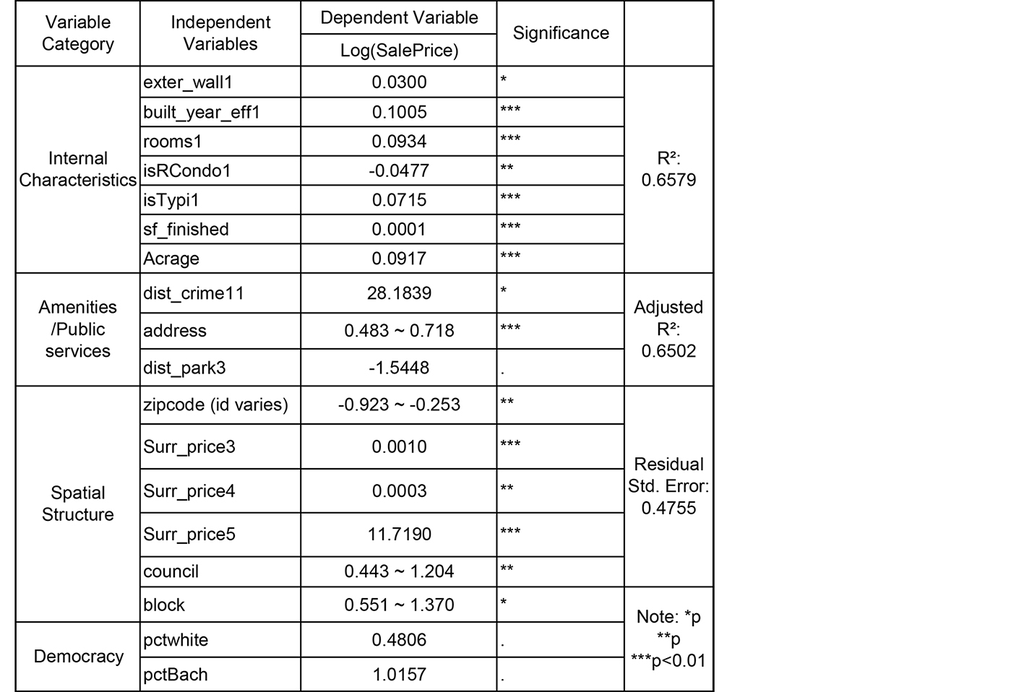

The independent variables listed are the ones of great significance, which means these variables have a strong relationship with the sale price.

#### *Accuracy for Test Set*

We tested the accuracy of our model on the randomly selected test set. To better evaluate the goodness of fit of the model, we used *$R^{2}$*, mean absolute error (*MAE*), and the mean absolute percentage error (*MAPE*). $R^{2}$ tells us the percentage of variance that is explained by the model, the *MAE* indicates the average difference between the observed value (real price) and the price predicted by our model. The result is presented in the table below.

Accuracy For Test set

| R.Squared | MAE | MAPE |
| --- | --- | --- |
| 0.657 | 129978 | 0.448 |

For every house, the mean error of our model is around `$130,000`, which is `44.8%` of the housing prices.

#### *Distribution of R^2*

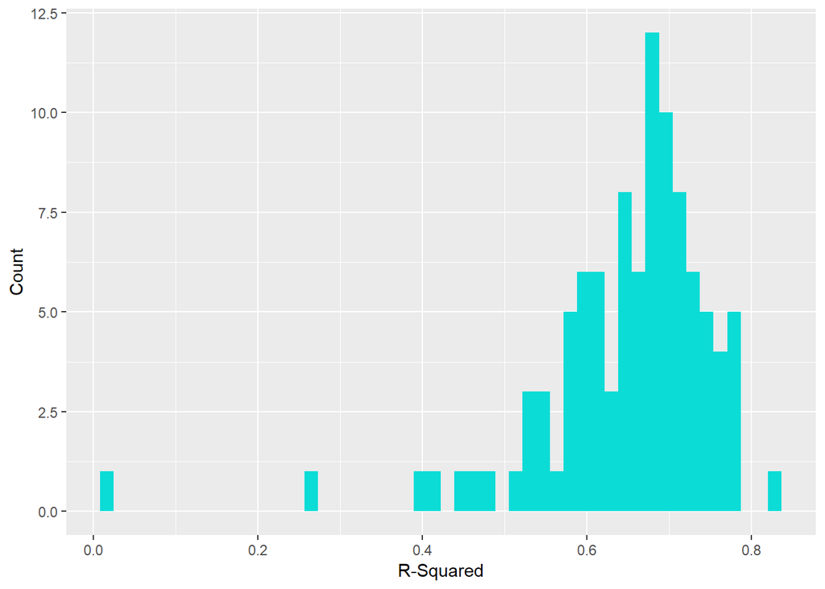

The mean of $R^{2}$ is `0.658`, the standard deviation of R² is `0.084`. Through the histogram of $R^{2}$, we could find that the distribution is concentrated around `0.7`, which means the difference from the actual value of each test is similar. Therefore, our model is generalizable to some extent.

#### *Predicted Prices vs. Observed Prices*

We plotted the predicted values and the actual values of every house in the figure below. Our actual prediction is drawn in the teal line. If we predict perfectly, the predicted values should equal the actual values (in red line).

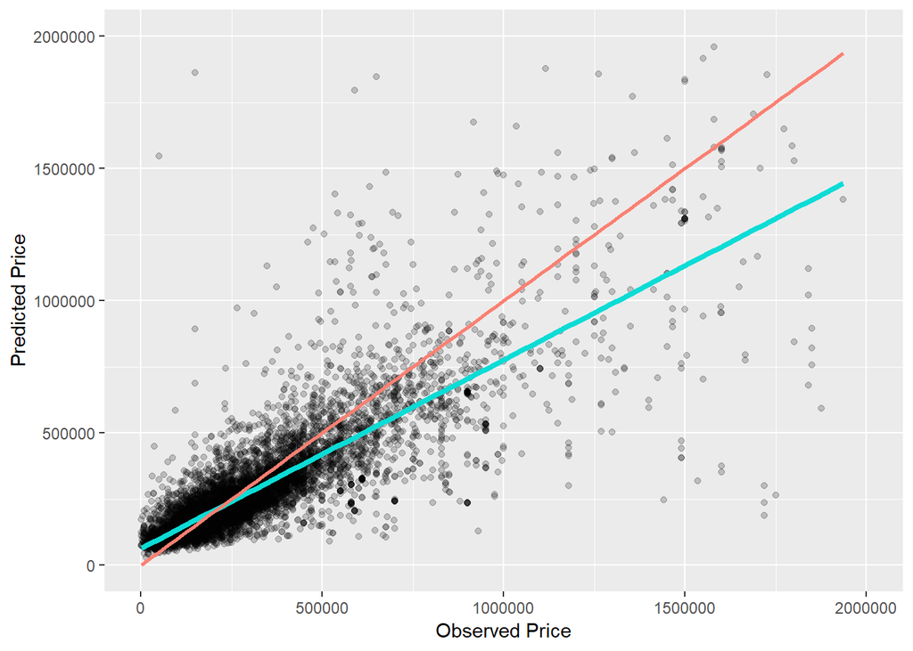

Please note the difference between the two lines. For most prices that are lower than $500,000, the difference is relatively small. However, while prices go up, the difference becomes larger.

#### *Map of Residuals for the 25% Randomly Selected Test set*

We presented the residuals in the figure below to check if the model takes **spatial variation** into account.

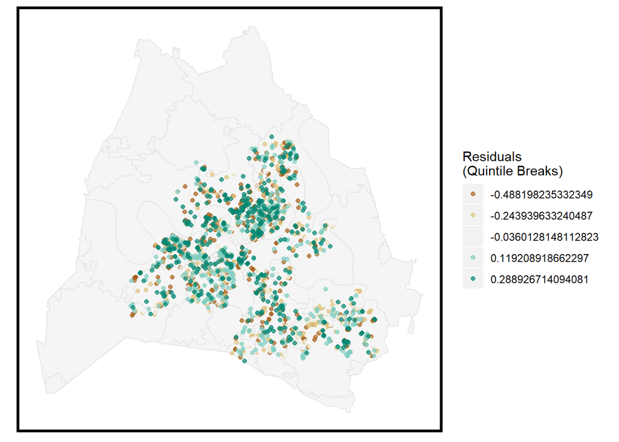

```
##
##  Moran I test under randomisation
##
## data:  reg6_05_residuals$residuals
## weights: nb2listw(spatialWeights, style = "W")
##
## Moran I statistic standard deviate = -0.35544, p-value = 0.6389
## alternative hypothesis: greater
## sample estimates:
## Moran I statistic       Expectation          Variance
##     -0.0053755869     -0.0004452360      0.0001924113
```

The residuals are not significantly clustered on the map, which means the model is comprehensive. The test result of Morans’ I is `-0.005`, which also proved the fact.

#### *Predicted House Price*

Below is a map of the predicted prices for the entire data set, including both the records with the actual sale price and the ones without.

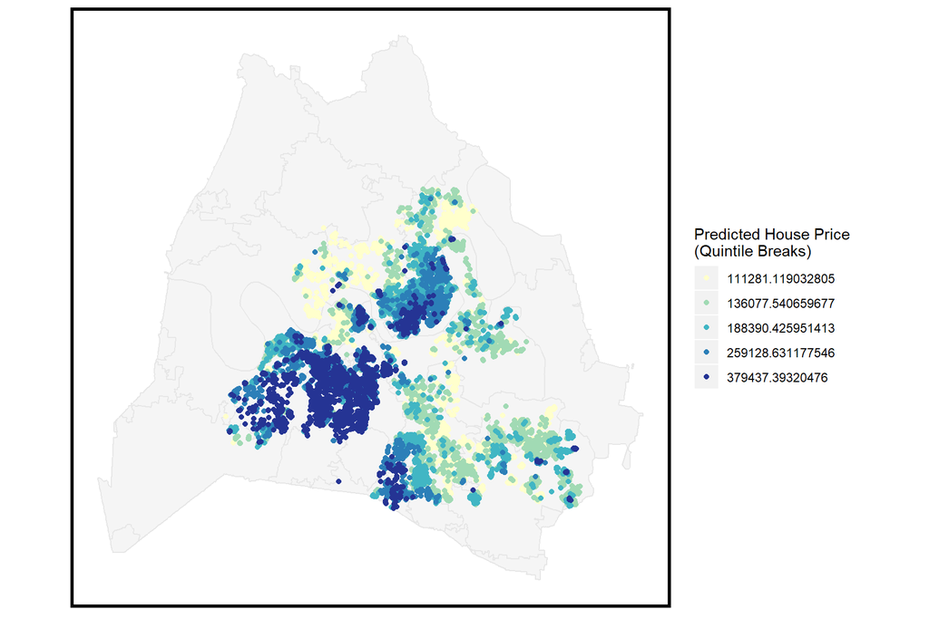

Comparing to the map of actual sale prices presented in **2 Data**, the prediction yielded by our model has a similar price distribution of the actual ones, but the prices vary.

#### *MAPE by Zip Code*

The MAPE by zip code map can show whether the model performs differently in different zip code districts.

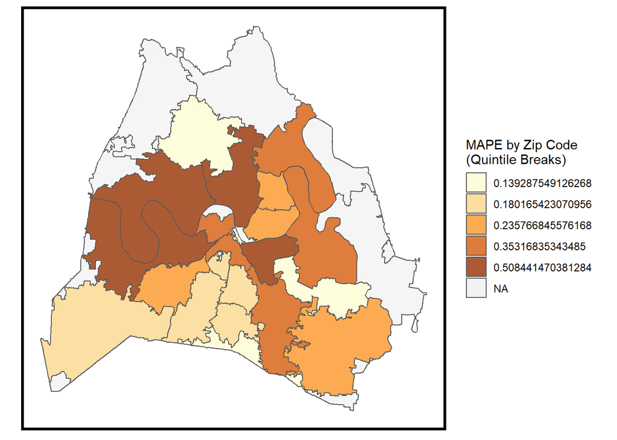

For districts that are close to the center city, the model offers more absolute error when predicting the sale price, which means this model is not generalizable enough for these districts.

#### *MAPE vs. Mean Price by Neighborhood*

To assess the **spatial generalizability** - comparable goodness of fit metrics across neighborhoods, we summarized the MAPE as a function of the mean price by neighborhoods.

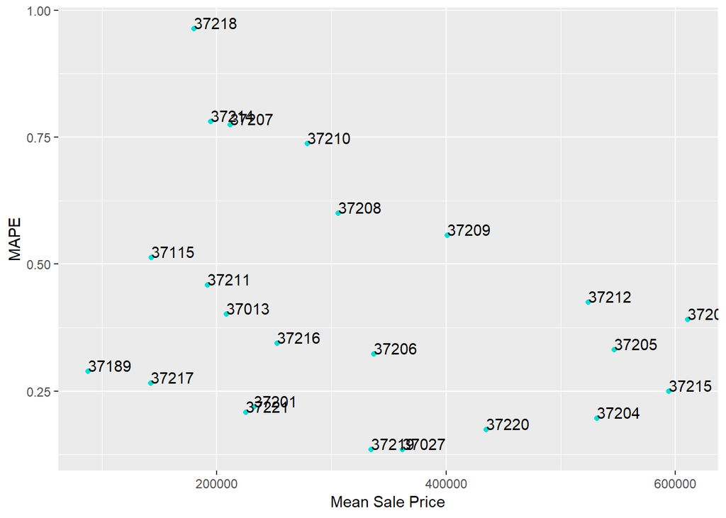

From the plot, we can see that there is no obvious relation between the mean sale price in a neighborhood and its MAPE. The **generalizability** of our model is acceptable according to the plot, but further quantitative analysis is needed.

#### *Spatial Cross-validation*

To quantitatively examine how our model performs in different kinds of neighborhoods, we conducted **“Spatial Cross-validation”**. The MAE and MAPE of the prediction when removing a rich/poor/middle-income neighborhood are shown in the table below: (For clarity, the code in this part is included)

```r
#rich:
vars6_nRich <-
  vars6_full %>%
  filter(GEOID != 47037018601)
vars6_Rich <-
  vars6_full %>%
  filter(GEOID == 47037018601)
reg6_rich <- lm(log(SalePrice) ~  isAC + baths + exter_wall + built_year_eff + rooms + isRCondo + isBasement + isTypi + sf_finished + Acrage + total_pop.2016 + med_HH_Income.2016 + pctWhite.2016 + pctBach + dist_park3 + dist_crime11 + address + zipcode + council + block + Surr_price3 + DISTRICT, data=vars6_nRich)
predicted_Rich <- data.frame(predictedVal = exp(predict(reg6_rich, vars6_Rich)))
predicted_Rich <- predicted_Rich %>%
  mutate(SalePrice = vars6_Rich$SalePrice,
         Error = predicted_Rich$predictedVal - vars6_Rich$SalePrice,
         Label = "Rich")
MAE_rich = mean(abs(predicted_Rich$predictedVal - vars6_Rich$SalePrice)) #MAE
MAPE_rich = round(mean(abs(predicted_Rich$predictedVal - vars6_Rich$SalePrice) / vars6_Rich$SalePrice), digits = 2) #MAPE
#poor:
vars6_nPoor <-
  vars6_full %>%
  filter(GEOID != 47037019300)
vars6_Poor <-
  vars6_full %>%
  filter(GEOID == 47037019300)
reg6_poor <- lm(log(SalePrice) ~  isAC + baths + exter_wall + built_year_eff + rooms + isRCondo + isBasement + isTypi + sf_finished + Acrage + total_pop.2016 + med_HH_Income.2016 + pctWhite.2016 + pctBach + dist_park3 + dist_crime11 + address + zipcode + council + Surr_price3 + DISTRICT, data=vars6_nPoor)
predicted_Poor <- data.frame(predictedVal = exp(predict(reg6_poor, vars6_Poor)))
predicted_Poor <- predicted_Poor %>%
  mutate(SalePrice = vars6_Poor$SalePrice,
         Error = predicted_Poor$predictedVal - vars6_Poor$SalePrice,
         Label = "Poor")
MAE_poor <- mean(abs(predicted_Poor$predictedVal - vars6_Poor$SalePrice)) #MAE
MAPE_poor <- round(mean(abs(predicted_Poor$predictedVal - vars6_Poor$SalePrice) / vars6_Poor$SalePrice), digits = 2) #MAPE
#middle-income:
vars6_nMiddle <-
  vars6_full %>%
  filter(GEOID != 47037011700)
vars6_Middle <-
  vars6_full %>%
  filter(GEOID == 47037011700)
reg6_Middle <- lm(log(SalePrice) ~  isAC + baths + exter_wall + built_year_eff + rooms + isRCondo + isBasement + isTypi + sf_finished + Acrage + total_pop.2016 + med_HH_Income.2016 + pctWhite.2016 + pctBach + dist_park3 + dist_crime11 + address + zipcode + council + Surr_price3 + DISTRICT, data=vars6_nMiddle)
predicted_Middle <- data.frame(predictedVal = exp(predict(reg6_Middle, vars6_Middle)))
predicted_Middle <- predicted_Middle %>%
  mutate(SalePrice = vars6_Middle$SalePrice,
         Error = predicted_Middle$predictedVal - vars6_Middle$SalePrice,
         Label = "Middle-income")
MAE_middle <- mean(abs(predicted_Middle$predictedVal - vars6_Middle$SalePrice)) #MAE
MAPE_middle <- round(mean(abs(predicted_Middle$predictedVal - vars6_Middle$SalePrice) / vars6_Middle$SalePrice), digits = 2) #MAPE
EC_table <- data.frame("Removed Neighborhood" = c("Rich", "Poor", "Middle-income"),
                       "MAE" = c(MAE_rich, MAE_poor, MAE_middle),
                       "MAPE" = c(MAPE_rich, MAPE_poor, MAPE_middle))
knitr::kable(
EC_table, caption = "Prediction Accuracy for Different Income Groups"
)
```

Prediction Accuracy for Different Income Groups

| Removed.Neighborhood | MAE | MAPE |
| --- | --- | --- |
| Rich | 3314460.12 | 3.78 |
| Poor | 127085.21 | 0.26 |
| Middle-income | 85042.79 | 0.38 |

For poor neighborhood and middle-income neighborhood, the MAE and MAPE are slightly better to the MAE/MAPE of the overall performance of our model. However, for rich neighbor, th model performed badly. The plots below can provide an intuitive sense of how the model performed.

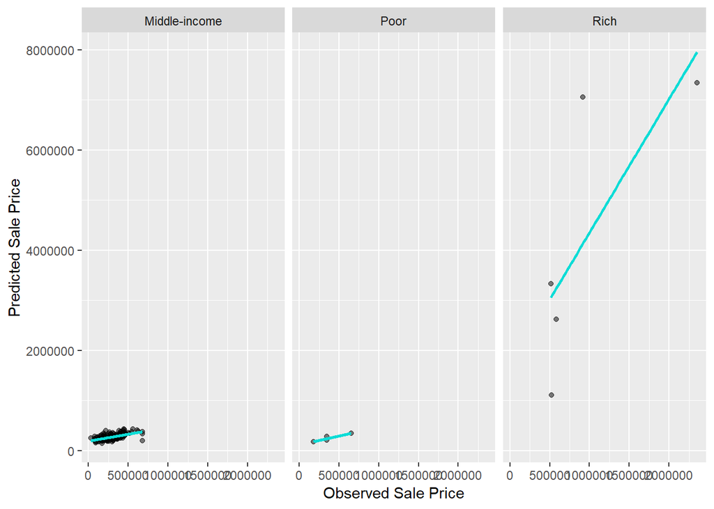

```r
predicted_Money <- rbind(predicted_Rich, predicted_Poor, predicted_Middle)
ggplot(predicted_Money, aes(x = SalePrice, y = predictedVal)) +
  geom_point(alpha = .5) +
  stat_smooth(method = "lm", se = FALSE, size =1, color = "#0cdcd6") +
  facet_wrap( ~ Label, ncol=3) +
  xlab("Observed Sale Price") +
  ylab("Predicted Sale Price")
```

The prices in the rich neighborhood are considerably higher than others, therefore, we “zoomed in” the plot to compare the performance when a poor or middle-income neighborhood is removed.

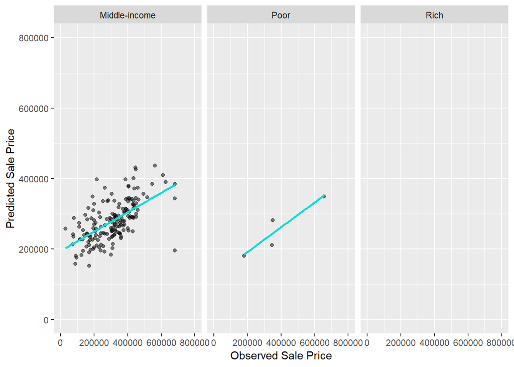

```r
ggplot(predicted_Money, aes(x = SalePrice, y = predictedVal)) +
  geom_point(alpha = .5) +
  stat_smooth(method = "lm", se = FALSE, size =1, color = "#0cdcd6") +
  facet_wrap( ~ Label, ncol=3) +
  xlab("Observed Sale Price") +
  ylab("Predicted Sale Price") +
  xlim(0, 800000) +
  ylim(0, 800000)
```

From the plot, we can conclude that the model predicted equally well when a poor or middle-income neighborhood is removed.

## 5 Discussion

In the prediction model, there are 26 variables in total. We took the internal characteristics of house, the amenities/public services in the neighborhood, and the spatial structure into account. Mean house price in nearby area, the proximity to incidents reported to police, and the school district that the property is located, are the most interesting three variables.

However, the model is still **not** effective enough, with `65.7%` of the variation in prices can be predicted. Among all the variables, the house price in surrounding houses improved the accuracy of the model the most.

From the map of residuals, we can tell the error of the prediction is not substantially clustered across space, indicating our model did account for the spatial variation in prices. However, the MAPE by Zip Code map shows there is still a difference in the accuracy of prediction across space.

Our model predicted particularly well in the relatively poor neighborhood, while the prediction results in the the rich neighborhood are not acceptable. Our model depends on the nearest several house prices, therefore, the poor prediction in the rich neighborhood could result from the relatively long distance between the houses.

## 6 Conclusion

We would recommend your model to *Zillow*. Our model is generalizable in a majority of place, and did well in taking spatial variation in house prices into account. Currently, the model is trained by at most 9,000 records with free open-source data using the most basic regression model. Therefore, if our model could be fueled with the astronomical amount of data from *Zillow*’s database and use more advanced spatial regression/machine learning model, we can improve the accuracy and generalizability greatly.